# Dynamic PINNs (5): Identifying Unknown Parameters using Inverse PINNs

An inverse PINN learns not just the solution to an ODE, but also an unknown physical parameter from noisy data. This notebook tackles the Duffing oscillator, treating the cubic stiffness alpha as unknown and recovering it from 250 noisy displacement measurements. We walk through the full pipeline, from ground-truth generation with solve_ivp, synthetic noise, input/output normalisation, and a three-part loss (IC, physics residual, data) to observing how the alpha parameter converges from zero to its true value over 30,000 training epochs.

pytorch

SciML

PINN

Author

Mei-Chin Pang

Published

June 20, 2026

# Learning Unknown Parameters from Inverse PINNs

## The Duffing Oscillator

$$\boxed{m\frac{d^2x}{dt^2} + c\frac{dx}{dt} + kx + \alpha x^3 = F\cos(\Omega t)}$$

This is the equation of motion for a **Duffing oscillator**, which is a nonlinear mass-spring-damper system driven by a harmonic force. It extends the classical forced damped harmonic oscillator by adding a cubic stiffness term $\alpha x^3$.

| Term | Meaning |
| --- | --- |
| $m({d^2x}/{dt^2})$ | Inertia: mass times acceleration. |
| $c({dx}/{dt})$ | Viscous damping: a velocity-proportional resistive force that dissipates energy. |
| $kx$ | Linear restoring force: the usual Hooke’s law spring term. |
| $\alpha x^3$ | **Duffing nonlinearity**: a cubic stiffness correction. For $\alpha > 0$ the spring stiffens at large displacements; for $\alpha < 0$ it softens. |
| $F\cos(\Omega t)$ | External harmonic forcing at frequency $\Omega$ and amplitude $F$. |

We treat $\alpha$ as **unknown** and use the inverse PINN to identify it from noisy displacement data. All other parameters ($m$, $c$, $k$, $F$, $\Omega$) are assumed known.

Initial conditions: $x(0) = 0.1$ m, ${dx}/{dt}(0) = 0$ m/s over $t \in [0, 30]$ s.

**NoteUnderstanding the Duffing oscillator**

**(a) What does this equation reduce to when $\alpha = 0$?**

With $\alpha = 0$, the equation becomes

$$m\frac{d^2x}{dt^2} + c\frac{dx}{dt} + kx = F\cos(\Omega t),$$

which is the **forced damped harmonic oscillator** (or linear mass-spring-damper). This is one of the most studied systems, where its behaviour is well understood: it exhibits a transient response that decays exponentially, followed by a steady-state sinusoidal oscillation at the forcing frequency $\Omega$, with amplitude determined by the distance between $\Omega$ and the natural frequency $\omega_n = \sqrt{k/m}$.

**(b) How does the $\alpha x^3$ term affect the oscillation?**

The $\alpha x^3$ term adds a **stiffness hardening** effect (for $\alpha > 0$) (*i.e.* the effective spring constant increases with displacement amplitude). A stiffer spring restores the mass more forcefully, so the oscillation frequency is **higher** than for a purely linear spring with the same small-displacement stiffness $k$. This means the resonance peak shifts to higher frequencies as amplitude increases, a hallmark feature of the Duffing oscillator. The phenomenon is called amplitude-frequency dependence or backbone curve shift.

## What makes this an inverse PINN?

In a **forward** PINN, every parameter in the ODE is known and the network only learns the solution $x(t)$. In an **inverse** PINN, one or more physical parameters are unknown. The network must learn both the solution and the parameter values simultaneously.

Here, the unknown is $\alpha$. We declare it as a learnable scalar using `torch.nn.Parameter`, initialised to zero:

```python
alpha_learnable = torch.nn.Parameter(torch.zeros(1, requires_grad=True, device=device))
optimiser = torch.optim.Adam(list(pinn.parameters()) + [alpha_learnable], lr=learning_rate)
```

Two things to note:

- `torch.nn.Parameter` wraps a tensor so that PyTorch tracks gradients with respect to it, just like a network weight. During backpropagation, $\hat\alpha$ receives a gradient and is updated by Adam alongside the network parameters.
- The optimiser is given `list(pinn.parameters()) + [alpha_learnable]`, the network weights **and** $\hat\alpha$ in a single parameter group. This means one `optimiser.step()` call updates everything: the network learns $x(t)$ while simultaneously nudging $\hat\alpha$ toward the true value.

## Physics residual

The ODE residual used in the physics loss is:

$$r = m\frac{d^2\hat{x}}{dt^2} + c\frac{d\hat{x}}{dt} + k\hat{x} + \hat\alpha\,\hat{x}^3 - F\cos(\Omega t)$$

This is the original Duffing equation rearranged so that $r = 0$ when the ODE is satisfied exactly. The key difference from a forward PINN is that $\hat\alpha$ is not a fixed constant, it is the learnable parameter that the optimiser adjusts during training. As the network’s displacement prediction $\hat{x}(t)$ improves (driven by the data loss), the physics loss forces $\hat\alpha$ to take whatever value makes $r \approx 0$ consistent with that displacement. The data and physics losses work together: the data anchors the trajectory shape, and the physics loss uses that shape to pin down $\alpha$.

**NoteUnderstanding the inverse PINN setup**

**(a) We initialise `alpha_learnable = 0`. Why is this reasonable, and how does the data loss correct it?**

Initialising `alpha_learnable = 0` means we start with the assumption of no cubic stiffness, which is the simplest possible model. This is a reasonable prior if we have no information about $\alpha$. The data loss then corrects this: at $\alpha = 0$, the network’s physics loss forces it to learn a solution that satisfies the linear ODE, which will not match the observed displacements (since the true data was generated with $\alpha = 1$). The mismatch between the network’s prediction and the data creates a gradient that flows back through the physics residual to `alpha_learnable`, gradually pushing it upward toward the value that makes the predicted trajectory match the observations.

**(b) What does $\partial\mathcal{L}_\text{phys}/\partial\hat\alpha$ represent?**

$\partial\mathcal{L}_\text{phys}/\partial\hat\alpha$ is the rate of change of the physics loss with respect to the estimated cubic stiffness:

$$\frac{2}{N_f}\sum_i r_i \cdot \hat{x}_i^3$$

so the gradient is large and positive when the residual $r_i$ is large and the predicted displacement $\hat{x}_i$ is large. The optimiser uses this gradient to decide how to adjust $\hat\alpha$: if increasing $\hat\alpha$ would reduce the residual (i.e. the current $\hat\alpha$ underestimates the true stiffness), the gradient will be negative and the optimiser will increase $\hat\alpha$.

**(c) Why is $\mathcal{L}_\text{data}$ especially critical here? What happens without it?**

Without data, the loss contains only $\mathcal{L}_\text{IC}$ and $\mathcal{L}_\text{phys}$. But the system $m\ddot{x} + c\dot{x} + kx + \hat\alpha x^3 = F\cos(\Omega t)$ with given ICs has a unique solution for *any* value of $\hat\alpha$ – each choice of $\hat\alpha$ gives a different but equally valid (self-consistent) trajectory. There is no mechanism to prefer $\hat\alpha = 1$ over $\hat\alpha = 0$ or $\hat\alpha = 5$. The data loss is what anchors the problem: it says “the solution must also match these specific observed values,” which constrains $\hat\alpha$ to the value consistent with those observations.

**(d) Give a real engineering scenario where $\alpha$ might be unknown. How would an inverse PINN help?**

One example: **structural health monitoring of a rubber vibration isolator**. Rubber isolators exhibit nonlinear stiffness (the $\alpha x^3$ term arises from the material’s hyperelastic behaviour), but the precise $\alpha$ depends on rubber compound, temperature, and ageing as it changes over the life of the component. Here, we can attach an accelerometer to the isolated mass (sensor data) and use an inverse PINN to identify the current $\alpha$ from the vibration response in operation, without needing to remove and test the isolator in a lab. This enables condition monitoring and remaining-life prediction.

**(e) Could we identify multiple unknown parameters simultaneously? What makes it harder?**

Yes, in principle, we can declare multiple `nn.Parameter` scalars ($\hat\alpha$, $\hat{c}$, etc.) and add them all to the optimiser. However, identifying multiple parameters is harder because:

- **identifiability**: different parameter combinations may produce similar responses, making it impossible to uniquely recover individual values from limited data;
- **loss landscape complexity**, more parameters create a higher-dimensional optimisation problem with more saddle points and local minima;
- **data requirements** increase: each additional unknown requires more diverse observations to constrain it independently. Careful experimental design (e.g. varying forcing frequency or amplitude) is often needed to make the multi-parameter problem well-posed.

# Model Architecture

**NoteTraining an inverse PINN**

**(a) What does `requires_grad=True` mean and why is it essential here?**

`requires_grad=True` tells PyTorch to track all operations performed on this tensor in the computational graph so that gradients can be computed with respect to it during backpropagation. It is essential here because `alpha_learnable` appears inside the physics residual calculation. Without `requires_grad=True`, PyTorch would not know to compute $\partial\mathcal{L}/\partial\hat\alpha$, so the optimiser would never update it, and it would remain fixed at its initial value of zero.

**(b) Why does identifying an unknown parameter require more training (30,000 epochs) than a forward PINN?**

The inverse problem has two coupled learning tasks that must be solved simultaneously:

- Learning the network weights to approximate $x(t)$.
- Estimating $\hat\alpha$.

These tasks are interacting, which mean the network cannot converge to the correct trajectory until $\hat\alpha$ is close to 1.0, and $\hat\alpha$ cannot converge until the network is producing a reasonable trajectory to generate meaningful physics residuals. This chicken-and-egg interaction slows convergence. Additionally, $\hat\alpha$ starts far from the truth (at 0), requiring many epochs for the gradient signal to accumulate enough to move it substantially. The 30-second time window also has more complex dynamics (transient + steady-state) requiring more capacity to represent.

# Inverse PINNs Implementation

```python
import time
import warnings

import matplotlib.pyplot as plt
import numpy as np
import torch
import torch.nn as nn
from scipy.integrate import odeint, solve_ivp
from tqdm import tqdm

plt.rcParams["text.usetex"] = True

# Suppress Intel Iris Xe "not officially supported" warning
warnings.filterwarnings(
    "ignore",
    message=".*detected GPU.*not officially supported by PyTorch XPU.*")

# Define the GPU type ("cuda" for NVIDIA GPUs, "xpu" for Intel GPUs)
gpu_type = "xpu"

if gpu_type == "cuda":
    device = torch.device("cuda" if torch.cuda.is_available() else "cpu")
elif gpu_type == "xpu":
    device = torch.device("xpu" if torch.xpu.is_available() else "cpu")
else:
    raise ValueError("Invalid GPU type. Use 'cuda' or 'xpu'.")

print(f"Using device: {device}")
```

```
Using device: cpu
```

# Numerical Ground Truth

## Physical parameters

The Duffing oscillator is configured with * $m = 1$ kg, * $k = 1$ N/m, * $c = 0.75$ Ns/m, * $F = 0.5$ N, and * $\Omega = 1$ rad/s. * The true cubic stiffness is $\alpha = 1$ N/m$^3$, which is the value the inverse PINN will try to recover. * The time window is $t \in [0, 30]$ s with 1,000 evaluation points.

## Converting to a first-order system

The Duffing equation is second-order, so we introduce velocity $v = \frac{dx}{dt}$ to write it as two first-order ODEs:

$$\frac{dx}{dt} = v, \qquad \frac{dv}{dt} = \frac{1}{m}\bigl[F\cos(\Omega t) - cv - kx - \alpha x^3\bigr]$$

The function `duffing_ode(t, y)` returns $[v,\, a]$ where $a = dv/dt$.

## `solve_ivp` vs `odeint`

Previous notebooks used `scipy.integrate.odeint`; this notebook uses `scipy.integrate.solve_ivp`. Both solve the same kind of problem, but with different interfaces:

| Aspects | `odeint` | `solve_ivp` |
| --- | --- | --- |
| **Function signature** | `f(y, t, ...)` (state first, then time) | `f(t, y)` (time first, then state) |
| **Call syntax** | `odeint(f, y0, t_array, args=(...))` | `solve_ivp(f, (t_start, t_end), y0, t_eval=..., method=...)` |
| **Duffing example** | `odeint(duffing_ode, y0, t_eval, args=(m, c, k, alpha, F, Omega))` | `solve_ivp(duffing_ode, (0, 30), y0, t_eval=t_eval, method='RK45')` |
| **Time points** | Solves at every point in `t_array` | Solves adaptively; use `t_eval` to specify output times |
| **Output shape** | `(n_times, n_vars)`: rows are time steps | `sol.y` has shape `(n_vars, n_times)`: columns are time steps |
| **Duffing output** | `sol[:, 0]` → displacement $x(t)$ | `sol.y[0, :]` → displacement $x(t)$ |
| **Default method** | `lsoda` (auto-switches stiff/non-stiff) | `RK45` (explicit Runge-Kutta) |
| **Status** | Legacy (still works, not deprecated) | Recommended by SciPy for new code |

The key practical differences to watch for:

- **Argument order is swapped:** `duffing_ode(t, y)` vs the `pendulum_system(y, t, ...)` used in previous notebooks. Because `solve_ivp` passes `(t, y)` directly, extra parameters ($m$, $c$, etc.) are captured from the enclosing scope rather than passed via `args`.
- **Output is transposed:** `sol.y[0, :]` gives displacement (first variable, all times), whereas `odeint` returns `solution[:, 0]` (all times, first variable).
- **`t_eval` keyword:** `solve_ivp` uses adaptive stepping internally and only returns output at `t_eval` points. Without `t_eval`, we get the solver’s own (irregular) time steps.

## Output

`sol.t` contains the 1,000 evaluation times: * `sol.y[0, :]` holds displacement $x(t)$ * `sol.y[1, :]` holds velocity ${dx}/{dt}(t)$.

Two plots show the displacement and velocity time histories separately.

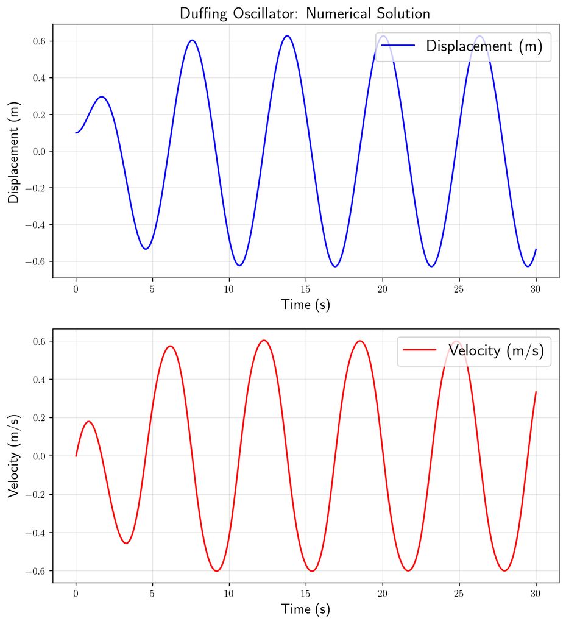

```python
# Physical parameters (alpha is the unknown we want to identify)
m     = 1.0    # mass (kg)
k     = 1.0    # linear stiffness (N/m)
c     = 0.75   # damping (Ns/m)
alpha = 1.0    # TRUE cubic stiffness — hidden from the PINN
F     = 0.5    # forcing amplitude (N)
Omega = 1.0    # forcing frequency (rad/s)

# ----------------------------------------------------------------------------
# Generate synthetic data by numerically solving the Duffing ODE
# with known parameters

# The Duffing equation is a second-order nonlinear ODE:
# m * x'' + c * x' + k * x + alpha * x^3 = F * cos(Omega * t)

# Initial condition: t=0
# x(0) = 0.1 m, x_dot(0) = 0 m/s
y0 = np.array([0.1, 0.0])

t_start, t_end = 0, 30
t_eval = np.linspace(t_start, t_end, 1000)


def duffing_ode(t, y):
    x, v = y
    a = (F * np.cos(Omega * t) - c * v - k * x - alpha * x**3) / m
    return [v, a]

# Numerically solve the Duffing ODE to generate "observed" data
sol   = solve_ivp(
    duffing_ode,
    (t_start, t_end),
    y0,
    t_eval=t_eval,
    method='RK45')
t     = sol.t
x     = sol.y[0, :]
x_dot = sol.y[1, :]

# ----------------------------------------------------------------------------
# Plot 1: Displacement time history
fig, axes = plt.subplots(
    2,1,
    figsize=(9, 10))

axes[0].plot(
    t, x,
    color='blue',
    label='Displacement (m)')
axes[0].set_xlabel(
    'Time (s)',
    fontsize=14)
axes[0].set_ylabel(
    'Displacement (m)',
    fontsize=14)
axes[0].set_title(
    'Duffing Oscillator: Numerical Solution',
    fontsize=16)
axes[0].legend(
    fontsize=16,
    loc='upper right')
axes[0].grid(True, alpha=0.3)

# ----------------------------------------------------------------------------
# Plot 2: Velocity time history
axes[1].plot(
    t, x_dot,
    color='red',
    label='Velocity (m/s)')
axes[1].set_xlabel(
    'Time (s)',
    fontsize=14)
axes[1].set_ylabel(
    'Velocity (m/s)',
    fontsize=14)
axes[1].legend(
    fontsize=16,
    loc='upper right')
axes[1].grid(True, alpha=0.3)
plt.show()
```

# Synthetic Experimental Data

## Why more data points for an inverse problem?

In a forward PINN the physics alone can guide the solution, the data loss is a helpful regulariser. In an inverse PINN the data is the *only* source of information about the unknown parameter $\alpha$. Without enough observations spread across the time window, the data loss cannot distinguish between different values of $\hat\alpha$, and the parameter estimate may not converge. 250 points gives the optimiser a denser signal to work with.

## Sampling strategy

250 time points are drawn uniformly at random from $[0, 30]$ s and sorted into chronological order. The ODE is solved at exactly these times via `solve_ivp` to obtain the “true” displacement values. Random (non-uniform) spacing mimics real sensor data.

## Adding noise

Each displacement value is perturbed with independent Gaussian noise of $\sigma = 0.01$ m. This is slightly larger than the $\sigma = 0.005$ used for the double pendulum, reflecting a noisier sensor environment. The noise makes the inverse problem harder. The PINN must learn to ignore measurement error while still extracting the correct $\alpha$ from the noisy trajectory shape.

## Overlay plot

The plot compares the 1,000-point numerical solution (blue curve) with the 250 noisy data points (black scatter). The noise should be visible but small relative to the oscillation amplitude, confirming a realistic signal-to-noise ratio.

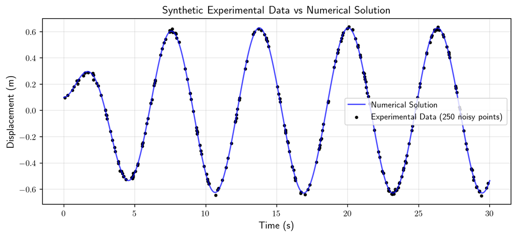

```python
# More data points than previous examples:
# inverse problems need denser observations
# to constrain the unknown parameter uniquely
N_exp_points = 250     # number of experimental observation points
exp_noise    = 0.01    # noise standard deviation (m)

# Generate synthetic "experimental" data by sampling the numerical solution
# at random time points and adding noise
# Sort the time points to ensure they are in ascending order for plotting
t_exp_np  = np.sort(
    np.random.rand(N_exp_points) * (t_end - t_start) + t_start)

# Solve the ODE at the experimental time points to get the "true" values
# before adding noise
sol_exp   = solve_ivp(
    duffing_ode, (t_start, t_end), y0, t_eval=t_exp_np, method='RK45')

# Add Gaussian noise to the displacement data to simulate measurement noise
x_exp_np  = sol_exp.y[0, :] + exp_noise * np.random.randn(N_exp_points)

# ---------------------------------------------------------------------------
plt.figure(figsize=(10, 4))
plt.plot(
    t, x,
    color='blue',
    label='Numerical Solution',
    alpha=0.7)
plt.scatter(
    t_exp_np, x_exp_np,
    color='black', s=8,
    label=f'Experimental Data ({N_exp_points} noisy points)')

plt.xlabel(
    'Time (s)',
    fontsize=12)
plt.ylabel(
    'Displacement (m)',
    fontsize=12)
plt.title(
    'Synthetic Experimental Data vs Numerical Solution',
    fontsize=13)
plt.legend()
plt.grid(True, alpha=0.3)
plt.show()
```

# Data Normalisation

This cell applies the same normalisation strategy used in previous notebooks, adapted for a single-output problem with a longer time window.

## Time normalisation

The raw experimental times $t \in [0, 30]$ are mapped to $[-1, +1]$:

$$\tilde{t} = \frac{2(t - t_\text{min})}{t_\text{max} - t_\text{min}} - 1$$

The longer time window ($[0, 30]$ vs $[0, 5]$ in the double pendulum) makes normalisation especially important. Without it, the raw time values would span a wide range, leading to large input magnitudes that destabilise training.

## Displacement normalisation

The displacement is standardised to zero mean and unit variance using the experimental data statistics:

$$\tilde{x} = \frac{x - \mu_x}{\sigma_x}$$

Unlike the coupled ODE notebook (which needed per-angle normalisation), here there is only one output variable, so a single pair of constants $(\mu_x, \sigma_x)$ suffices.

## Tensor conversion

- `t_exp_norm` has shape `(250, 1)`: a column vector of normalised times.
- `x_exp_norm` has shape `(250, 1)`: a column vector of normalised displacements.

```python
t_min, t_max = t_start, t_end
dt           = t_max - t_min

# Calculate mean and std of the experimental displacement data
# for standardisation
x_mean = np.mean(x_exp_np)
x_std  = np.std(x_exp_np)

# ---------------------------------------------------------------------------
# Normalise time to [-1, +1]
t_exp_norm_np = 2 * (t_exp_np - t_min) / dt - 1.0

# ---------------------------------------------------------------------------
# Standardise displacement to zero mean, unit variance
x_exp_norm_np = (x_exp_np - x_mean) / x_std

# Convert to PyTorch tensors and move to device
t_exp_norm = (torch.from_numpy(t_exp_norm_np)
              .float().view(-1, 1).to(device))
x_exp_norm = (torch.from_numpy(x_exp_norm_np)
              .float().view(-1, 1).to(device))

print("t_exp_norm range: "
      f"[{t_exp_norm.min():.3f}, {t_exp_norm.max():.3f}]"
      "  (should be near [-1, +1])")
print(f"x_exp_norm mean:  {x_exp_norm.mean():.4f}"
      "  (should be ~0.0)")
print(f"x_exp_norm std:   {x_exp_norm.std():.4f}"
      "   (should be ~1.0)")
```

```
t_exp_norm range: [-0.995, 0.992]  (should be near [-1, +1])
x_exp_norm mean:  -0.0000  (should be ~0.0)
x_exp_norm std:   1.0020   (should be ~1.0)
```

# Network Definition and Training Setup

## Neural network architecture

The same `FullyConnectedNN` architecture used in previous notebooks, configured for a single-output inverse problem:

| Component | Code | Description |
| --- | --- | --- |
| `fcs` | `Linear(1, 64) + Tanh` | Input layer: maps normalised time to 64 hidden units. |
| `fch` | 2 x `Linear(64, 64) + Tanh` | Hidden layers: two additional layers (`N_LAYERS - 1 = 2`). |
| `fce` | `Linear(64, 1)` | Output layer: maps to one normalised displacement $\tilde{x}$ (no activation). |

Note this uses 3 hidden layers (not 4 as in the coupled ODE), since the Duffing oscillator has only one output variable and less complex coupling structure.

## Normalisation helpers

- `normalise_t(t_tensor)`: maps raw physical time to $[-1, +1]$.
- `denormalise_x(x_tensor)`: reverses the standardisation $\hat{x} = \tilde{x} \cdot \sigma_x + \mu_x$ to recover physical displacement.

## The inverse PINN addition

The key difference from a forward PINN is `alpha_learnable`, a scalar `nn.Parameter` initialised to 0, representing the unknown cubic stiffness $\hat\alpha$. It is added to the optimiser alongside the network weights:

```python
optimiser = torch.optim.Adam(
    list(pinn.parameters()) + [alpha_learnable], ...)
```

This means each `optimiser.step()` call updates both the network weights (to improve the displacement prediction) and $\hat\alpha$ (to improve the physics residual). The `alpha_history` list records $\hat\alpha$ at every epoch so we can plot its convergence toward the true value.

## Training configuration

- **Architecture:** 1 input, 3 hidden layers of 64 units, 1 output.
- **Collocation points:** 1,000 uniformly spaced in $[0, 30]$ s with `requires_grad=True`.
- **Boundary point:** $t = 0$ for the IC loss ($x(0) = 0.1$, $\dot{x}(0) = 0$).
- **Loss weights:** all set to 1.
- **Optimiser:** Adam with LR $= 10^{-3}$, applied to network weights **and** `alpha_learnable`.
- **LR scheduler:** `StepLR` halves the learning rate every 5,000 epochs (at 5k, 10k, 15k, 20k, 25k).
- **Epochs:** 30,000, longer than forward PINNs due to the coupled weight-and-parameter learning problem.

```python
torch.manual_seed(42)

class FullyConnectedNN(nn.Module):

    def __init__(self, N_INPUT, N_OUTPUT, N_HIDDEN, N_LAYERS):
        super().__init__()

        # Tanh activation
        activation = nn.Tanh

        # Define the fully connected layers of the PINN
        # The first layer maps the input to the hidden dimension,
        # followed by Tanh activation
        self.fcs = nn.Sequential(nn.Linear(N_INPUT, N_HIDDEN), activation())

        # The hidden layers consist of N_LAYERS-1 blocks of Linear + Tanh
        self.fch = nn.Sequential(*[
            nn.Sequential(nn.Linear(N_HIDDEN, N_HIDDEN), activation())
            for _ in range(N_LAYERS - 1)])

        # The final layer maps the hidden dimension to the output dimension
        self.fce = nn.Linear(N_HIDDEN, N_OUTPUT)

    # The forward method defines how the input data flows through the network
    def forward(self, x):
        x = self.fcs(x); x = self.fch(x); x = self.fce(x)
        return x

# ---------------------------------------------------------------------------
# Normalisation helpers
def normalise_t(t_tensor):
    return 2.0 * (t_tensor - t_min) / dt - 1.0

# Denormalisation helper for the PINN output (displacement)
def denormalise_x(x_tensor):
    return x_tensor * x_std + x_mean

# ---------------------------------------------------------------------------
# PINNs hyperparameters
n_input = 1
n_output = 1
n_hidden = 64
n_layers = 3
epochs = 30000
learning_rate = 1e-3

# Loss weights for the different components of the PINN loss function
lambda_boundary = 1
lambda_physics = 1
lambda_data = 1

# ---------------------------------------------------------------------------
# Instantiate the PINN and move it to the appropriate device (GPU or CPU)
pinn = FullyConnectedNN(
    n_input,
    n_output,
    n_hidden,
    n_layers).to(device)

# ---------------------------------------------------------------------------
# Inverse problem setup: we want to learn the unknown parameter alpha
# alpha_learnable is a scalar nn.Parameter initialised to 0
# (we pretend we don't know alpha; it starts as 'no cubic stiffness')
# requires_grad=True lets PyTorch track gradients through it
alpha_learnable = torch.nn.Parameter(
    torch.zeros(1, requires_grad=True, device=device)
)
alpha_history = []

# ---------------------------------------------------------------------------
# Initial condition time point (t=0) for the initial condition loss
t_ic = torch.tensor([
    [0.0]],
    device=device,
    requires_grad=True)

# We sample the physics loss at N_phys points in the time domain
N_phys  = 1000

# t_phys is a column vector of time points from t_start to t_end,
# with requires_grad=True so we can compute derivatives w.r.t. time
t_phys  = torch.linspace(
    t_start, t_end, N_phys, device=device).view(-1, 1)
t_phys.requires_grad_(True)

# alpha_learnable is passed to Adam alongside the network weights
optimiser = torch.optim.Adam(
    list(pinn.parameters()) + [alpha_learnable],
    lr=learning_rate)

# Learning rate scheduler to reduce the learning rate by half
# every 5000 epochs
scheduler = torch.optim.lr_scheduler.StepLR(
    optimiser,
    step_size=5000,
    gamma=0.5)


print(f"Network parameters:"
      + f"{sum(p.numel() for p in pinn.parameters())}")
print(f"alpha_learnable initialised to: "
      + f"{alpha_learnable.item():.4f}  (target: {alpha})")
print(f"Training for {epochs} epochs...")
```

```
Network parameters:8513
alpha_learnable initialised to: 0.0000  (target: 1.0)
Training for 30000 epochs...
```

# PINN Training Loop

Each epoch executes four parts, then updates both the network weights and $\hat\alpha$.

## Part 1: Initial Condition (IC) Loss

1. Normalise $t = 0$ and forward-pass to get $\tilde{x}(0)$.
2. Denormalise to physical displacement.
3. Compute $dx/dt$ at $t = 0$ via `torch.autograd.grad`.
4. Penalise deviations from both initial values:

$$\mathcal{L}_\text{IC} = (\hat{x}(0) - 0.1)^2 + \left(\frac{d\hat{x}}{dt}(0)\right)^2$$

## Part 2: Physics (Duffing ODE Residual) Loss

1. Normalise the 1,000 collocation times and forward-pass to get normalised predictions.
2. Denormalise to physical displacement $\hat{x}$.
3. Compute first and second derivatives via two calls to `torch.autograd.grad` (both with `create_graph=True`).
4. Evaluate the Duffing ODE residual using **`alpha_learnable`** (not the true $\alpha$):

$$r = m\frac{d^2\hat{x}}{dt^2} + c\frac{d\hat{x}}{dt} + k\hat{x} + \hat\alpha\,\hat{x}^3 - F\cos(\Omega t)$$

$$\mathcal{L}_\text{phys} = \text{mean}(r^2)$$

This is where the inverse learning happens: because `alpha_learnable` appears in $r$, backpropagation computes $\partial\mathcal{L}_\text{phys}/\partial\hat\alpha$ and the optimiser adjusts $\hat\alpha$ to reduce the residual.

## Part 3: Data Loss (in normalised space)

$$\mathcal{L}_\text{data} = \text{mean}\!\bigl[(\tilde{\hat{x}} - \tilde{x}^\text{exp})^2\bigr]$$

This anchors the trajectory shape so that $\hat\alpha$ converges to the value consistent with the observed data.

## Part 4: Total Loss and Weight Update

$$\mathcal{L_\text{total}} = \lambda_\text{IC}\,\mathcal{L}_\text{IC} + \lambda_\text{phys}\,\mathcal{L}_\text{phys} + \lambda_\text{data}\,\mathcal{L}_\text{data}$$

`total_loss.backward()` computes gradients for both the network weights and `alpha_learnable`. `optimiser.step()` updates all of them via Adam. After each epoch, the current value of $\hat\alpha$ is appended to `alpha_history` so we can plot its convergence.

```python
total_loss_history = []
ic_loss_history = []
physics_loss_history = []
data_loss_history = []

start_training_time = time.time()

for i in range(epochs + 1):
    optimiser.zero_grad()

    # -----------------------------------------------------------------------
    # Part 1: Initial Condition Loss
    t_boundary_norm = normalise_t(t_ic)
    x_boundary_norm = pinn(t_boundary_norm)
    x_boundary      = denormalise_x(x_boundary_norm)
    dx_dt_boundary  = torch.autograd.grad(
        x_boundary, t_ic,
        torch.ones_like(x_boundary), create_graph=True)[0]

    # Squared error between predicted displacement at t=0 and 0.1 m
    loss_x_boundary  = torch.mean((x_boundary - 0.1) ** 2)

    # Squared error between predicted velocity at t=0 and 0.0 m/s
    loss_dx_boundary = torch.mean((dx_dt_boundary - 0.0) ** 2)

    loss_boundary = loss_x_boundary + loss_dx_boundary

    # -----------------------------------------------------------------------
    # Part 2: Physics (Residual) Loss
    t_physics_norm = normalise_t(t_phys)
    x_physics_norm = pinn(t_physics_norm)
    x_physics      = denormalise_x(x_physics_norm)

    dx_dt   = torch.autograd.grad(
        x_physics, t_phys,
        torch.ones_like(x_physics), create_graph=True)[0]
    d2x_dt2 = torch.autograd.grad(
        dx_dt, t_phys,
        torch.ones_like(dx_dt), create_graph=True)[0]

    # Duffing ODE residual with alpha_learnable
    # r = m*(d2x/dt2) + c*(dx/dt) + k*x + alpha_hat*x^3 - F*cos(Omega*t)
    # Backprop through this line updates alpha_learnable toward
    # the true alpha=1.0
    r_physics    = (
        m*d2x_dt2
        + c*dx_dt
        + k*x_physics
        + alpha_learnable*(x_physics**3)
        - F*torch.cos(Omega*t_phys))
    loss_physics = torch.mean(r_physics ** 2)

    # -----------------------------------------------------------------------
    # Part 3: Data Loss (normalised space)
    x_data_norm = pinn(t_exp_norm)
    loss_data   = torch.mean((x_data_norm - x_exp_norm) ** 2)

    # -----------------------------------------------------------------------
    # Part 4: Total Loss
    total_loss = (lambda_boundary * loss_boundary
        + lambda_physics * loss_physics
        + lambda_data * loss_data)


    # Track alpha parameter history for plotting later
    alpha_history.append(alpha_learnable.item())

    # Track different loss components for plotting later
    total_loss_history.append(total_loss.item())
    ic_loss_history.append(loss_boundary.item())
    physics_loss_history.append(loss_physics.item())
    data_loss_history.append(loss_data.item())

    total_loss.backward()
    optimiser.step()
    scheduler.step()

    if i % 1000 == 0 or i == epochs:
        print(f"Epoch {i:>5d}/{epochs}  "
              f"Loss: {total_loss.item():.6f}  "
              f"alpha: {alpha_learnable.item():.4f}")

end_training_time = time.time()
training_duration = end_training_time - start_training_time

print(f"\nTraining complete.")
print(f"Training duration:     {training_duration:.4f} seconds")
print(f"Final loss:            {total_loss_history[-1]:.6f}")
print(f"Identified alpha:      {alpha_learnable.item():.4f}")
print(f"True alpha:            {alpha:.4f}")
print(f"Error:                 {abs(alpha_learnable.item() - alpha):.4f}")
```

[output not shown]

# Evaluation and Plots

## PINN displacement prediction

300 evenly spaced test points are generated over $[0, 30]$ s, normalised, and passed through the trained network inside `torch.no_grad()` (no gradient tracking needed at inference). The normalised output is denormalised back to physical displacement for plotting.

## Plot 1: Displacement comparison

This plot overlays five elements:

- **PINN prediction** (black solid line): the trained network’s displacement $\hat{x}(t)$.
- **Numerical solution** (red dashed line): the ground-truth `solve_ivp` result. If training succeeded, the two curves should be nearly indistinguishable.
- **Experimental data** (black scatter): the 250 noisy observations used for training.
- **Physics collocation points** (grey scatter at $x = 0$): a visual indication of where the ODE residual was enforced. These are shown at $x = 0$ for display purposes only – the actual residual was evaluated at the network’s predicted displacement.
- **Boundary point** (red dot at $(0, 0.1)$): the initial condition.

## Plot 2: Training loss

The total loss on a log scale over 30,000 epochs. Orange dashed lines mark the LR reduction points (every 5,000 epochs). Each reduction should produce a visible drop in loss as the optimiser enters a finer convergence regime.

## Plot 3: $\alpha$ parameter convergence

The centrepiece of this notebook. This plot shows `alpha_history`, which is the value of $\hat\alpha$ at every epoch converging from its initial value of 0 toward the true value $\alpha = 1.0$ (red dashed horizontal line). The convergence curve reveals how quickly and smoothly the inverse PINN identifies the unknown parameter. Typically $\hat\alpha$ rises rapidly in the first few thousand epochs (as the network begins producing a reasonable trajectory), then refines gradually as the displacement prediction improves.

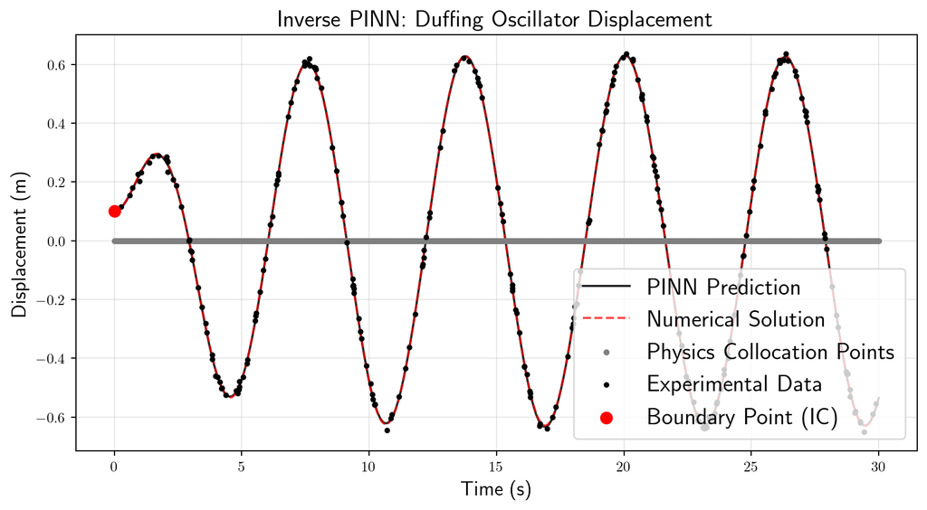

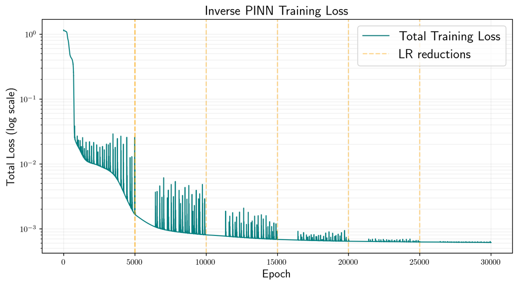

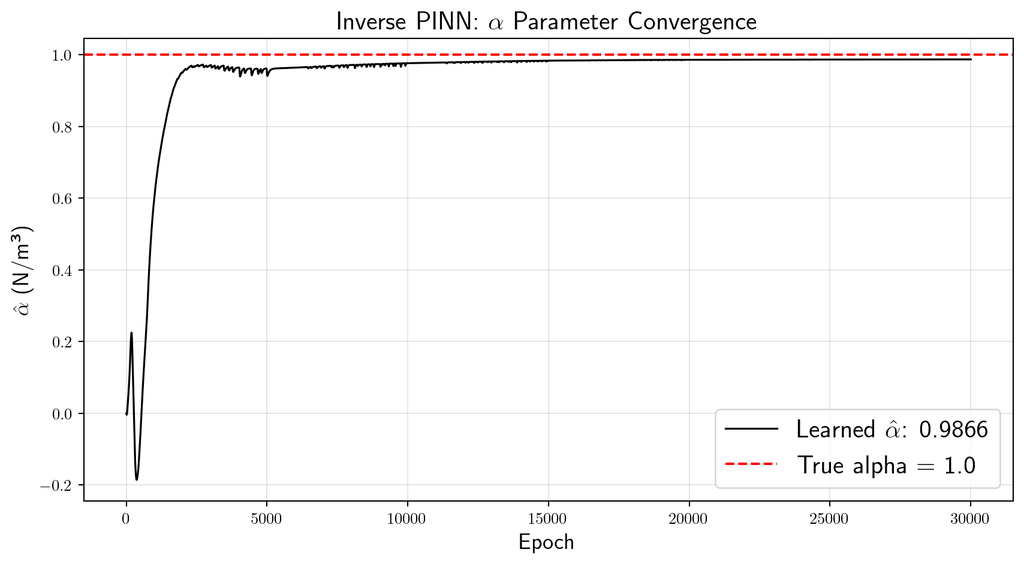

```python
# PINN predictions for plotting
t_test      = torch.linspace(t_start, t_end, 300, device=device).view(-1, 1)
t_test_norm = normalise_t(t_test)

# We use torch.no_grad() to avoid tracking gradients during inference,
# which saves memory and computation since we don't need to update the model
# during evaluation.
with torch.no_grad():
    x_pred_norm = pinn(t_test_norm)
    x_pred      = denormalise_x(x_pred_norm)

t_plot = t_test[:, 0].detach().cpu().numpy()
x_plot = x_pred[:, 0].detach().cpu().numpy()


# Convert t_phys to CPU numpy for plotting the collocation points
t_phys_np = t_phys.detach().cpu().numpy()

# ---------------------------------------------------------------------------
# Plot 1: Displacement time history with PINN prediction, numerical solution,
# physics collocation points, and experimental data
plt.figure(figsize=(9, 5))

# Plot PINN prediction
plt.plot(
    t_plot, x_plot,
    color='black',
    label='PINN Prediction',
    alpha=0.85)

# Plot the original numerical solution for reference
plt.plot(
    t, x,
    color='red',
    linestyle='dashed',
    label='Numerical Solution',
    alpha=0.7)

# Plot the physics collocation points
plt.scatter(
    t_phys_np,
    np.zeros_like(t_phys_np),
    color='grey',
    s=10,
    label='Physics Collocation Points',
    zorder=3)

# Plot the experimental data points
plt.scatter(
    t_exp_np, x_exp_np,
    color='black',
    s=8,
    label='Experimental Data',
    zorder=4)
plt.scatter(
    [0], [0.1],
    color='red',
    s=60,
    zorder=5,
    label='Boundary Point (IC)')
plt.xlabel('Time (s)', fontsize=14)
plt.ylabel('Displacement (m)', fontsize=14)
plt.title('Inverse PINN: Duffing Oscillator Displacement', fontsize=16)
plt.legend(fontsize=16)
plt.grid(True, alpha=0.3)
plt.tight_layout()
plt.show()

# ---------------------------------------------------------------------------
# Plot 2: Training loss
plt.figure(figsize=(9, 5))
plt.plot(
    total_loss_history,
    color='teal',
    linewidth=1.2,
    label='Total Training Loss')

for ep in [5000, 10000, 15000, 20000, 25000]:
    plt.axvline(x=ep, color='orange', linestyle='--', alpha=0.4)

plt.axvline(
    x=5000,
    color='orange',
    linestyle='--',
    alpha=0.4,
    label='LR reductions')

plt.yscale('log')
plt.xlabel('Epoch', fontsize=14)
plt.ylabel('Total Loss (log scale)', fontsize=14)
plt.title('Inverse PINN Training Loss', fontsize=16)
plt.legend(fontsize=16)
plt.grid(True, which='both', linestyle='-', alpha=0.2)
plt.tight_layout()
plt.show()

# ---------------------------------------------------------------------------
# Plot 3: Alpha convergence - the centrepiece of this notebook
plt.figure(figsize=(9, 5))
plt.plot(
    alpha_history,
    color='black',
    linewidth=1.2,
    label=fr'Learned $\hat\alpha$: {alpha_learnable.item():.4f}')

plt.axhline(
    y=alpha,
    color='red',
    linestyle='--',
    linewidth=1.5,
    label=f'True alpha = {alpha}')
plt.xlabel('Epoch', fontsize=14)
plt.ylabel(r'$\hat\alpha$ (N/m³)', fontsize=14)
plt.title(r'Inverse PINN: $\alpha$ Parameter Convergence', fontsize=16)
plt.legend(fontsize=16)
plt.grid(True, alpha=0.3)
plt.tight_layout()
plt.show()
```

# References

1. Francis Fernandes (2026). Mastering Dynamic PINNs.